# Analysis of bootcamp survey

Rick Gilmore

2017-08-17 12:11:36

## Goals

- Download and clean data from 2017 R Bootcamp Survey
- Visualize data
- Prepare reports in `ioslides_presentation`, `pdf_document`, and `word_document` formats

## Preliminaries

Load required packages.

```r
library(tidyverse)
library(googlesheets)
```

## Load data and examine

The survey data are stored in a [Google Sheet](https://docs.google.com/spreadsheets/d/1Ay56u6g4jyEEdlmV2NHxTLBlcjI2gHavta-Ik0kGrpg/edit#gid=896447063). We’ll use the `googlesheets` package to open it and create a data frame. Documentation about the package can be found [here](https://cran.r-project.org/web/packages/googlesheets/vignettes/basic-usage.html).

There are some idiosyncrasies in using the `googlesheets` package in an R Markdown document because it requires interaction with the console, so I created a separate R script, `Get_bootcamp_googlesheet.R` to extract the survey data. If you try to execute the next chunk, it may give you an error, or it may ask you to allow `googlesheets` to access information in your Google profile.

```r
# Set eval=FALSE so I can render non-notebook formats
source("../R/Get_bootcamp_googlesheet.R")
```

This script downloads the data file saves it to a CSV under `data/survey.csv`.We can then load this file.

I also created a test data file, `data/survey-test.csv` so I could see how everything worked before y’all filled out your responses. The `R/Make_test_survey.R` file shows how I did this. It’s a great, reproducible practice to **simulate the data you expect**, then run it through your pipeline.

```r
# Created test data set for testing.
# survey <- read_csv("../data/survey-test.csv")
# Or choose data from respondents
survey <- read_csv("../data/survey.csv")
```

```r
survey
```

| Timestamp | Your current level of experience/expertise with R | Your enthusiasm for Game of Thrones | Age in years | Preferred number of hours spent sleeping/day | Favorite day of the week | Are your data tidy? |
| --- | --- | --- | --- | --- | --- | --- |
| NA | NA | NA | NA | NA | NA | NA |
| 8/13/2017 23:29:24 | some | 10 | 28 | 8!!! | Friday | Yes |
| 8/14/2017 12:01:12 | some | 10 | 22 | 7 | Friday | That's a personal question |
| 8/15/2017 12:42:09 | some | 10 | 24 | 10 | Saturday | No |
| 8/15/2017 17:13:08 | none | 10 | 28 | 9 | Saturday | Yes |
| 8/15/2017 19:03:40 | limited | 10 | 24 | 9 | Saturday | No |
| 8/15/2017 23:36:07 | some | 10 | 23 | 6-7 | Friday | Yes |
| 8/15/2017 23:45:05 | limited | 3 | 25 | 8 | Friday | Yes |
| 8/16/2017 0:26:01 | pro | 9 | 37 | 7 | Friday | That's a personal question |
| 8/16/2017 1:09:44 | none | 10 | 25 | 9 | Saturday | No |

[output cut: 29 more lines]

The `str()` or ‘structure’ command is also a great way to see what you’ve got.

```r
str(survey)
```

```
Classes ‘tbl_df’, ‘tbl’ and 'data.frame':   39 obs. of  7 variables:
 $ Timestamp                                        : chr  NA "8/13/2017 23:29:24" "8/14/2017 12:01:12" "8/15/2017 12:42:09" ...
 $ Your current level of experience/expertise with R: chr  NA "some" "some" "some" ...
 $ Your enthusiasm for Game of Thrones              : int  NA 10 10 10 10 10 10 3 9 10 ...
 $ Age in years                                     : int  NA 28 22 24 28 24 23 25 37 25 ...
 $ Preferred number of hours spent sleeping/day     : chr  NA "8!!!" "7" "10" ...
 $ Favorite day of the week                         : chr  NA "Friday" "Friday" "Saturday" ...
 $ Are your data tidy?                              : chr  NA "Yes" "That's a personal question" "No" ...
 - attr(*, "spec")=List of 2
  ..$ cols   :List of 7
  .. ..$ Timestamp                                        : list()
  .. .. ..- attr(*, "class")= chr  "collector_character" "collector"
  .. ..$ Your current level of experience/expertise with R: list()
  .. .. ..- attr(*, "class")= chr  "collector_character" "collector"
  .. ..$ Your enthusiasm for Game of Thrones              : list()
  .. .. ..- attr(*, "class")= chr  "collector_integer" "collector"
  .. ..$ Age in years                                     : list()
  .. .. ..- attr(*, "class")= chr  "collector_integer" "collector"
  .. ..$ Preferred number of hours spent sleeping/day     : list()
  .. .. ..- attr(*, "class")= chr  "collector_character" "collector"
  .. ..$ Favorite day of the week                         : list()
  .. .. ..- attr(*, "class")= chr  "collector_character" "collector"
  .. ..$ Are your data tidy?                              : list()
  .. .. ..- attr(*, "class")= chr  "collector_character" "collector"
  ..$ default: list()
  .. ..- attr(*, "class")= chr  "collector_guess" "collector"
  ..- attr(*, "class")= chr "col_spec"
```

Clearly, we need to do some cleaning before we can do anything with this.

Let’s start by renaming variables.

```r
names(survey) <- c("Timestamp",
                  "R_exp",
                  "GoT",
                  "Age_yrs",
                  "Sleep_hrs",
                  "Fav_day",
                  "Tidy_data")
```

```r
# complete.cases() drops NAs
survey <- survey[complete.cases(survey),]
survey
```

| Timestamp | R_exp | GoT | Age_yrs | Sleep_hrs | Fav_day | Tidy_data |
| --- | --- | --- | --- | --- | --- | --- |
| 8/13/2017 23:29:24 | some | 10 | 28 | 8!!! | Friday | Yes |
| 8/14/2017 12:01:12 | some | 10 | 22 | 7 | Friday | That's a personal question |
| 8/15/2017 12:42:09 | some | 10 | 24 | 10 | Saturday | No |
| 8/15/2017 17:13:08 | none | 10 | 28 | 9 | Saturday | Yes |
| 8/15/2017 19:03:40 | limited | 10 | 24 | 9 | Saturday | No |
| 8/15/2017 23:36:07 | some | 10 | 23 | 6-7 | Friday | Yes |
| 8/15/2017 23:45:05 | limited | 3 | 25 | 8 | Friday | Yes |
| 8/16/2017 0:26:01 | pro | 9 | 37 | 7 | Friday | That's a personal question |
| 8/16/2017 1:09:44 | none | 10 | 25 | 9 | Saturday | No |
| 8/16/2017 8:51:05 | limited | 1 | 23 | 7.5 | Thursday | No |

[output cut: 28 more lines]

Now, lets make sure we have numbers where we expect them. That person who really likes 8 hours (“8!!!”) is a problem (for me, not them).

```r
survey$Sleep_hrs <- readr::parse_number(survey$Sleep_hrs)
survey
```

| Timestamp | R_exp | GoT | Age_yrs | Sleep_hrs | Fav_day | Tidy_data |
| --- | --- | --- | --- | --- | --- | --- |
| 8/13/2017 23:29:24 | some | 10 | 28 | 8.0 | Friday | Yes |
| 8/14/2017 12:01:12 | some | 10 | 22 | 7.0 | Friday | That's a personal question |
| 8/15/2017 12:42:09 | some | 10 | 24 | 10.0 | Saturday | No |
| 8/15/2017 17:13:08 | none | 10 | 28 | 9.0 | Saturday | Yes |
| 8/15/2017 19:03:40 | limited | 10 | 24 | 9.0 | Saturday | No |
| 8/15/2017 23:36:07 | some | 10 | 23 | 6.0 | Friday | Yes |
| 8/15/2017 23:45:05 | limited | 3 | 25 | 8.0 | Friday | Yes |
| 8/16/2017 0:26:01 | pro | 9 | 37 | 7.0 | Friday | That's a personal question |
| 8/16/2017 1:09:44 | none | 10 | 25 | 9.0 | Saturday | No |
| 8/16/2017 8:51:05 | limited | 1 | 23 | 7.5 | Thursday | No |

[output cut: 28 more lines]

Looks good. Let’s save that cleaned file so we don’t have to do this again.

```r
write_csv(survey, path="../data/survey_clean.csv")
```

We may want to make the `R_exp` variable ordered.

```r
(survey_responses <- unique(survey$R_exp))
```

```
[1] "some"    "none"    "limited" "pro"
```

This shows us the different survey response values.

```r
survey$R_exp <- ordered(survey$R_exp, levels=c("none",
                                               "limited",
                                               "some",
                                               "lots",
                                               "pro"))
```

## Visualization

Now, we follow Mike Meyer’s advice: “Plot your data!”

### Descriptive plots

```r
R_exp_hist <- survey %>%
  ggplot() +
  aes(x=R_exp) +
  geom_histogram(stat = "count") # R_exp is discrete
```

```
Ignoring unknown parameters: binwidth, bins, pad
```

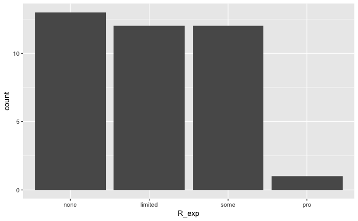

```r
R_exp_hist
```

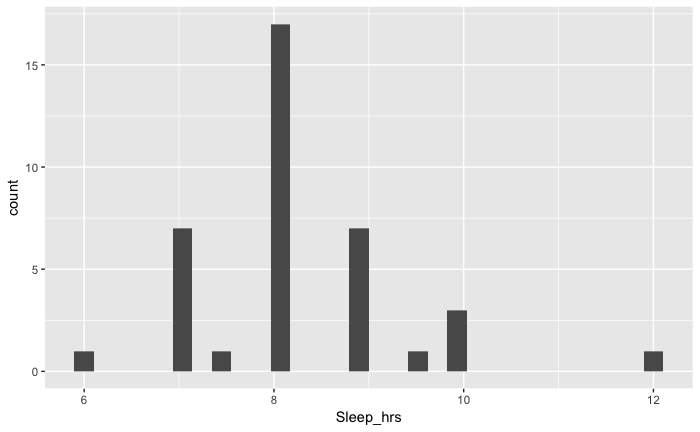

```r
Sleep_hrs_hist <- survey %>%
  ggplot() +
  aes(x=Sleep_hrs) +
  geom_histogram() # Sleep_hrs is continuous
Sleep_hrs_hist
```

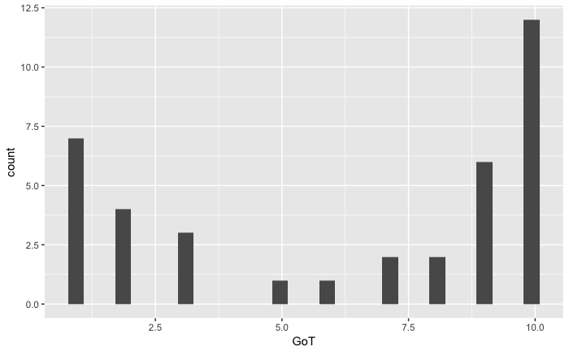

```r
Got_hist <- survey %>%
  ggplot() +
  aes(x=GoT) +
  geom_histogram()
Got_hist
```

Looks like we are of two minds about GoT.

[figure not shown]

Does R experience have any relation to GoT enthusiasm?

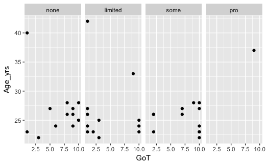

```r
GoT_vs_r_exp <- survey %>%
  ggplot() +
  aes(x=GoT, y=Age_yrs) +
  facet_grid(. ~ R_exp) +
  geom_point()
GoT_vs_r_exp
```

```r
tidy_hist <- survey %>%
  ggplot() +
  aes(x=Tidy_data) +
  geom_histogram(stat = "count")
```

```
Ignoring unknown parameters: binwidth, bins, pad
```

[figure not shown]

```r
tidy_hist
```

## Analysis

I could use a document like this to plan out my analysis plan **before** I conduct it. If I used simulated data, I could make sure that my workflow will run when I get real (cleaned) data. I could even preregister my analysis plan before I conduct it. That doesn’t preclude later exploratory analyses, but it does hold me and my collaborators accountable for what I predicted in advance.

## Notes

Notice that I sometimes put a label like `got-vs-r-exp` in the brackets for a given ‘chunk’ of R code. The main reasons to do this are:

- It sometimes makes it easier to debug your code.
- In some cases, you can have this ‘chunk’ name serve as the file name for a figure you generate within a chunk.
- In a bit, we’ll see how these chunk names are useful for making tables, figures, and equations that generate their own numbers.